# HOMEWORK_9

Matteo Vantaggio

2024-10-27

## Exploratory Data Analysis

The dataset comprises time series data from four distinct rainfall stations (T4219, T4220, T4237, and T438). Each record includes two columns: the date and the corresponding rainfall amount recorded on that day. The dataset contains a total of 7,304 observations, spanning 20 years of data collection from 1951 to 1970.

Each time series looks like this

```
##         date r_amount
## 1 1951-01-01      0.0
## 2 1951-01-02      0.6
## 3 1951-01-03      0.0
## 4 1951-01-04     11.2
## 5 1951-01-05     10.5
## 6 1951-01-06      0.0
```

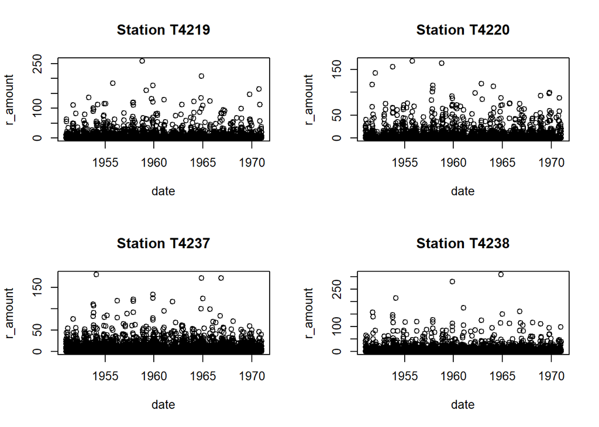

```r
par(mfrow = c(2, 2))
plot(ts1, main = "Station T4219")
plot(ts2, main = "Station T4220")
plot(ts3, main = "Station T4237")
plot(ts4, main = "Station T4238")
```

In order to check for missing values, we sum and locate them as follows

```r
na_counts <- sapply(list(ts1, ts2, ts3, ts4), function(ts) sum(is.na(ts[, 2])))
names(na_counts) <- c("ts1", "ts2", "ts3", "ts4")
print(na_counts)
```

```
## ts1 ts2 ts3 ts4
##   3   3   3   3
```

```r
where <- sapply(list(ts1, ts2, ts3, ts4), function(ts) which(is.na(ts1[,2])))
print(where)
```

```
##      [,1] [,2] [,3] [,4]
## [1,] 1826 1826 1826 1826
## [2,] 3653 3653 3653 3653
## [3,] 5479 5479 5479 5479
```

As we can see, the three missing observation for each time series are the same, which means we can impute them in the same way. We are going to discuss three ways of imputing the missing values in the dataset, ultimately choosing only one. The proposed methods are discussed on the first time series only, just for simplicity. The choosen method is being applied to all four time series. The first way is by linear interpolation, and it gives us the following values

```r
missing_indices_ts1 <- which(is.na(ts1$r_amount))
time_index <- as.numeric(as.Date(ts1$date))
rainfall <- ts1$r_amount
interpolated_values_ts1 <- approx(x = time_index, y = rainfall, xout = time_index)$y
imputed_values_linear_ts1 <- interpolated_values_ts1[missing_indices_ts1]
print(imputed_values_linear_ts1)
```

```
## [1] 0.0 0.1 0.0
```

The second method is LOESS and its output is the following. Note that the function used “loess” needs the tuning of the parameter ‘span’ which accounts for the smoothness of the curve: a smaller span captures more local detail, while a larger span produces a smoother fit

```r
loess_fit_ts1 <- loess(r_amount ~ as.numeric(as.Date(date)), data = ts1, span = 0.1)
imputed_values_loess_ts1 <- predict(loess_fit_ts1, newdata = ts1[missing_indices_ts1, ])
print(imputed_values_loess_ts1)
```

```
##     1826     3653     5479
## 4.036511 2.656301 2.296764
```

The third approach is by computing a mean of a 30-days window in which the missing value is the middle observation.

```r
missing_indices_ts1_mean <- which(is.na(ts1$r_amount))
window_size <- 15
ts1$r_amount[missing_indices_ts1_mean[1]] <- mean(ts1$r_amount[(missing_indices_ts1_mean - window_size)[1]:(missing_indices_ts1_mean + window_size)[1]], na.rm = TRUE)
ts1$r_amount[missing_indices_ts1_mean[2]] <- mean(ts1$r_amount[(missing_indices_ts1_mean - window_size)[2]:(missing_indices_ts1_mean + window_size)[2]], na.rm = TRUE)
ts1$r_amount[missing_indices_ts1_mean[3]] <- mean(ts1$r_amount[(missing_indices_ts1_mean - window_size)[3]:(missing_indices_ts1_mean + window_size)[3]], na.rm = TRUE)
ts1$r_amount[missing_indices_ts1_mean]
```

```
## [1] 3.626667 3.706667 0.900000
```

The last two methods seem to produce similar values, but the third one will be chosen since it does not rely on tuning the span parameter in the ‘loess’ function. Therefore, these are the imputed values for the remaining three rain stations

```
## [1] 3.7300000 3.6800000 0.4366667
```

```
## [1] 2.56 7.97 8.47
```

```
## [1] 1.986667 6.840000 5.423333
```

## Generalized Extreme Value: block maxima approach.

In order to fit a gev model, we first need to search an appropriate time window using block maxima. The goal here is to divide the time series into sequences of some length n and pick the maxima of each block, controlling for uncorrelation. Therefore a key role is played by the length of the blocks: it must be large enough so that the maxima are uncorrelated (in order for the Fisher-Tippet-Gnedenko Theorem to be applied) but small enough so that we end up with a reasonable amount of data points. Hence, if we can meet the assumptions that all data points come from the same population with unknown density function and that all the values are taken independently, then we can estimate a model for our data and by FTG theorem the distribution of the maxima converge to one of the three probability distributions: Gumbel, Fréchet and Weibull.

```r
data1 <- ts1 %>%
  mutate(
    year = year(date),
    month = month(date),
    quarter = ceiling(month / 6)
  )
gev_data1 <- data1 %>%
  group_by(year, quarter) %>%
  summarize(
    start_date = min(date),
    end_date = max(date),
    max_rainfall = max(r_amount, na.rm = TRUE),
    .groups = "drop"
  )
print(gev_data1)
```

```
## # A tibble: 40 × 5
##     year quarter start_date          end_date            max_rainfall
##    <dbl>   <dbl> <dttm>              <dttm>                     <dbl>
##  1  1951       1 1951-01-01 00:00:00 1951-06-30 00:00:00         63.5
##  2  1951       2 1951-07-01 00:00:00 1951-12-31 00:00:00        111.
##  3  1952       1 1952-01-01 00:00:00 1952-06-30 00:00:00         36.2
##  4  1952       2 1952-07-01 00:00:00 1952-12-31 00:00:00         79.5
##  5  1953       1 1953-01-01 00:00:00 1953-06-30 00:00:00        136.
##  6  1953       2 1953-07-01 00:00:00 1953-12-31 00:00:00         99.6
##  7  1954       1 1954-01-01 00:00:00 1954-06-30 00:00:00        112.
##  8  1954       2 1954-07-01 00:00:00 1954-12-31 00:00:00        116.
##  9  1955       1 1955-01-01 00:00:00 1955-06-30 00:00:00        115.
## 10  1955       2 1955-07-01 00:00:00 1955-12-31 00:00:00        184.
## # ℹ 30 more rows
```

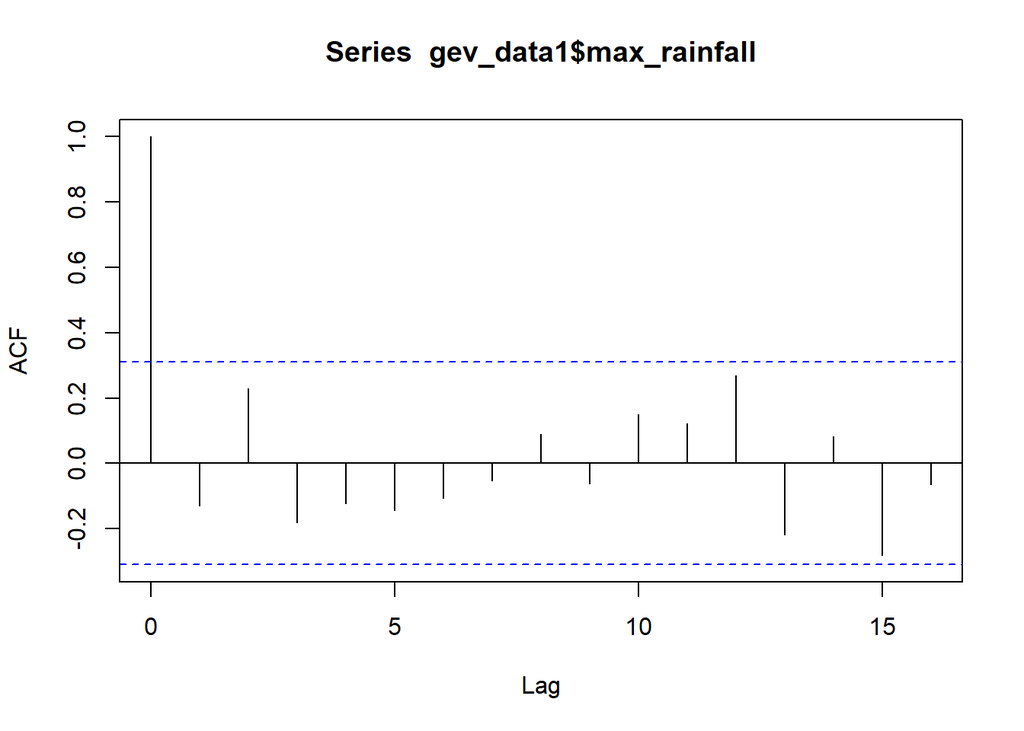

```r
acf(gev_data1$max_rainfall)
```

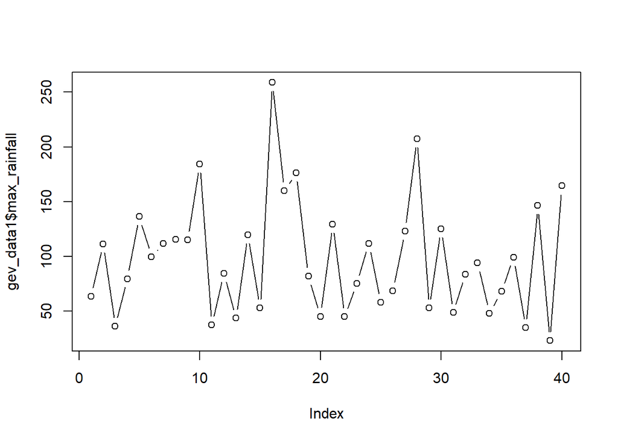

```r
plot(gev_data1$max_rainfall, type = "b")
```

The choice of the length of the time window has been preformed by looking at plot of the autocorrelation function: after trying with 3 and 4 months time window, the first plot where auotocorrelation was not present in the data has been found with a 6 months time window. In order to apply the same code to each series, a function has been built

```r
# Function to compute the block maxima for a given time series
compute_maxima <- function(ts_data, station_name) {
  data <- ts_data %>%
    mutate(year = year(date), month = month(date), quarter = ceiling(month / 6))

  maxima_data <- data %>%
    group_by(year, quarter) %>%
    summarize(max_rainfall = max(r_amount, na.rm = TRUE), .groups = "drop")

  return(maxima_data)
}

maxima_ts1 <- compute_maxima(ts1, "T4219")
maxima_ts2 <- compute_maxima(ts2, "T4220")
maxima_ts3 <- compute_maxima(ts3, "T4237")
maxima_ts4 <- compute_maxima(ts4, "T4238")
```

At this point we can fit the GEV model for each time series, plot some diagnostics, compute the 95% confidence intervals for the parameters, the return levels of order 100,200,500,1000 and their respective confidence intervals.

```r
# Time Series 1: T4219
GEV_ts1 <- fevd(maxima_ts1$max_rainfall, type = "GEV")
summary(GEV_ts1)
```

```
##
## fevd(x = maxima_ts1$max_rainfall, type = "GEV")
##
## [1] "Estimation Method used: MLE"
##
##
##  Negative Log-Likelihood Value:  210.949
##
##
##  Estimated parameters:
##    location       scale       shape
## 72.76529263 38.35666583  0.08060203
##
##  Standard Error Estimates:
##  location     scale     shape
## 7.2324789 5.6000925 0.1634106
##
##  Estimated parameter covariance matrix.
##            location     scale       shape
## location 52.3087504 21.570718 -0.53063783
## scale    21.5707176 31.361036 -0.35401898
## shape    -0.5306378 -0.354019  0.02670302
##
##  AIC = 427.898
##
##  BIC = 432.9646
```

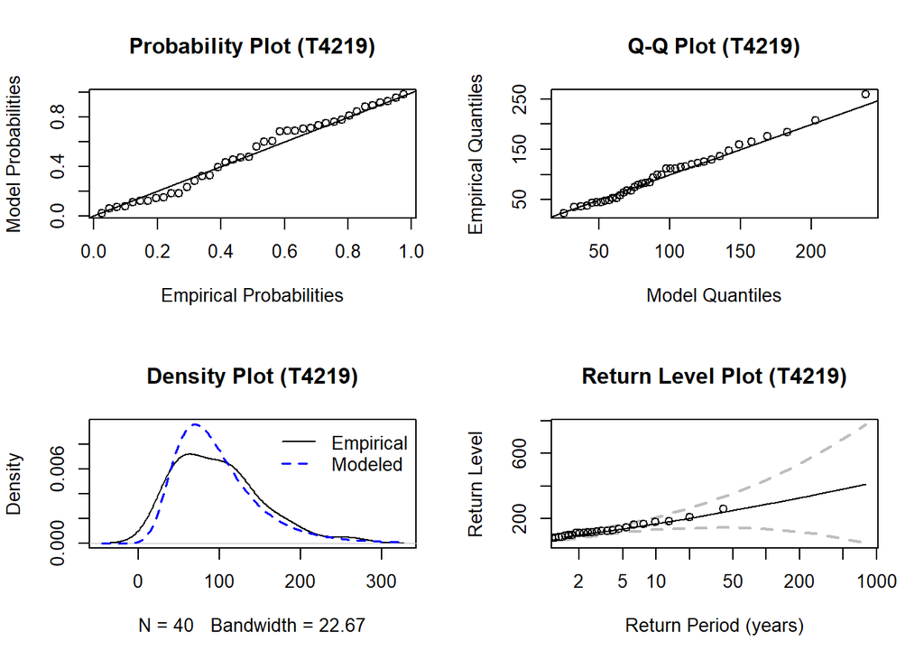

```r
# 95% confidence intervals for GEV parameters (normal approximation)
norm_cint_ts1 <- ci(GEV_ts1, alpha = 0.05, type = "parameter")
print(norm_cint_ts1)
```

```
## fevd(x = maxima_ts1$max_rainfall, type = "GEV")
##
## [1] "Normal Approx."
##
##          95% lower CI    Estimate 95% upper CI
## location   58.5898946 72.76529263   86.9406907
## scale      27.3806862 38.35666583   49.3326454
## shape      -0.2396768  0.08060203    0.4008809
```

```r
# Return levels with 95% confidence intervals
ret_lev_ts1 <- return.level(GEV_ts1, return.period = c(100, 200, 500, 1000),
                            do.ci = TRUE)
ret_lev_ts1
```

```
## fevd(x = maxima_ts1$max_rainfall, type = "GEV")
##
## [1] "Normal Approx."
##
##                        95% lower CI Estimate 95% upper CI
## 100-year return level     135.56890 286.3705     437.1721
## 200-year return level     117.16729 326.1355     535.1037
## 500-year return level      76.41477 382.1279     687.8411
## 1000-year return level     31.77539 427.2807     822.7860
```

```r
# Time Series 2: T4220
GEV_ts2 <- fevd(maxima_ts2$max_rainfall, type = "GEV")
summary(GEV_ts2)
```

```
##
## fevd(x = maxima_ts2$max_rainfall, type = "GEV")
##
## [1] "Estimation Method used: MLE"
##
##
##  Negative Log-Likelihood Value:  199.1566
##
##
##  Estimated parameters:
##    location       scale       shape
## 54.91702538 29.45070198  0.02449262
##
##  Standard Error Estimates:
##  location     scale     shape
## 5.3454684 3.9632135 0.1348709
##
##  Estimated parameter covariance matrix.
##            location      scale       shape
## location 28.5740329  9.1766915 -0.28226162
## scale     9.1766915 15.7070613 -0.17561323
## shape    -0.2822616 -0.1756132  0.01819017
##
##  AIC = 404.3132
##
##  BIC = 409.3798
```

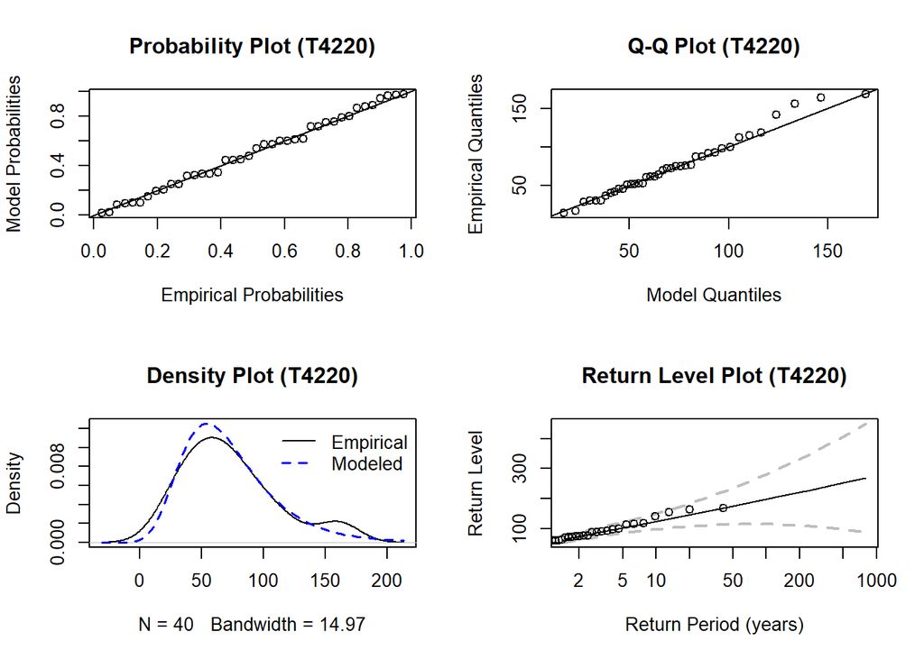

```r
norm_cint_ts2 <- ci(GEV_ts2, alpha = 0.05, type = "parameter")
norm_cint_ts2
```

```
## fevd(x = maxima_ts2$max_rainfall, type = "GEV")
##
## [1] "Normal Approx."
##
##          95% lower CI    Estimate 95% upper CI
## location   44.4400997 54.91702538   65.3939510
## scale      21.6829463 29.45070198   37.2184577
## shape      -0.2398496  0.02449262    0.2888348
```

```r
# Return levels with 95% confidence intervals
ret_lev_ts2 <- return.level(GEV_ts2, return.period = c(100, 200, 500, 1000),
                            do.ci = TRUE)
ret_lev_ts2
```

```
## fevd(x = maxima_ts2$max_rainfall, type = "GEV")
##
## [1] "Normal Approx."
##
##                        95% lower CI Estimate 95% upper CI
## 100-year return level     115.63121 198.3217     281.0121
## 200-year return level     110.97377 221.4493     331.9248
## 500-year return level      97.85719 252.5710     407.2848
## 1000-year return level     82.53983 276.5606     470.5814
```

```r
# Time Series 3: T4237
GEV_ts3 <- fevd(maxima_ts3$max_rainfall, type = "GEV")
summary(GEV_ts3)
```

```
##
## fevd(x = maxima_ts3$max_rainfall, type = "GEV")
##
## [1] "Estimation Method used: MLE"
##
##
##  Negative Log-Likelihood Value:  183.4497
##
##
##  Estimated parameters:
##   location      scale      shape
## 56.8473141 14.6797565  0.5683629
##
##  Standard Error Estimates:
## location    scale    shape
## 2.680062 2.696843 0.171586
##
##  Estimated parameter covariance matrix.
##            location      scale       shape
## location  7.1827341 5.52536778 -0.11636420
## scale     5.5253678 7.27295983  0.05734842
## shape    -0.1163642 0.05734842  0.02944175
##
##  AIC = 372.8995
##
##  BIC = 377.9661
```

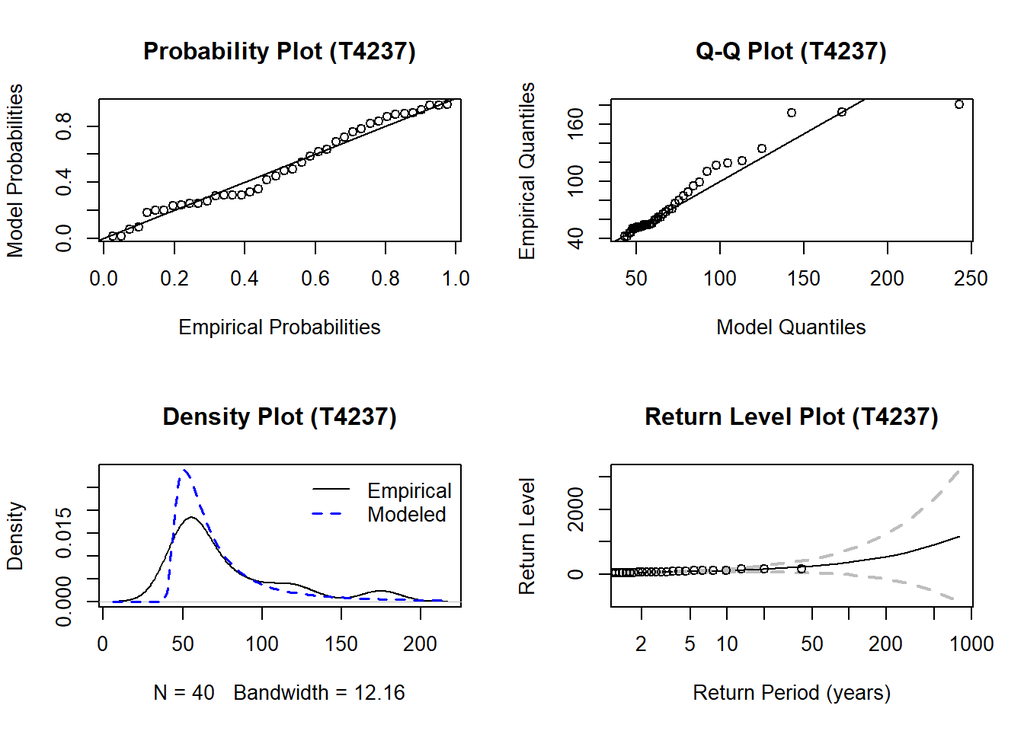

```r
# Diagnostic plots for T4237
par(mfrow = c(2, 2))
plot(GEV_ts3, type = c("probprob"), main = "Probability Plot (T4237)")
plot(GEV_ts3, type = c("qq"), main = "Q-Q Plot (T4237)")
plot(GEV_ts3, type = c("density"), main = "Density Plot (T4237)")
plot(GEV_ts3, type = c("rl"), main = "Return Level Plot (T4237)")
```

```r
# 95% confidence intervals for GEV parameters (normal approximation)
norm_cint_ts3 <- ci(GEV_ts3, alpha = 0.05, type = "parameter")
norm_cint_ts3
```

```
## fevd(x = maxima_ts3$max_rainfall, type = "GEV")
##
## [1] "Normal Approx."
##
##          95% lower CI   Estimate 95% upper CI
## location   51.5944885 56.8473141   62.1001398
## scale       9.3940422 14.6797565   19.9654708
## shape       0.2320605  0.5683629    0.9046652
```

```r
# Return levels with 95% confidence intervals
ret_lev_ts3 <- return.level(GEV_ts3, return.period = c(100, 200, 500, 1000),
                            do.ci = TRUE)
ret_lev_ts3
```

```
## fevd(x = maxima_ts3$max_rainfall, type = "GEV")
##
## [1] "Normal Approx."
##
##                        95% lower CI  Estimate 95% upper CI
## 100-year return level     -1.296566  383.8606     769.0177
## 200-year return level   -129.057887  554.9751    1239.0081
## 500-year return level   -495.351554  913.7747    2322.9010
## 1000-year return level -1043.010035 1340.3768    3723.7637
```

```r
# Time Series 4: T4238
GEV_ts4 <- fevd(maxima_ts4$max_rainfall, type = "GEV")
summary(GEV_ts4)
```

```
##
## fevd(x = maxima_ts4$max_rainfall, type = "GEV")
##
## [1] "Estimation Method used: MLE"
##
##
##  Negative Log-Likelihood Value:  210.9946
##
##
##  Estimated parameters:
##   location      scale      shape
## 70.3399071 35.5339501  0.2204672
##
##  Standard Error Estimates:
##  location     scale     shape
## 6.5139449 5.2595816 0.1472862
##
##  Estimated parameter covariance matrix.
##          location     scale       shape
## location 42.43148 20.572130 -0.34240002
## scale    20.57213 27.663198 -0.11447198
## shape    -0.34240 -0.114472  0.02169322
##
##  AIC = 427.9892
##
##  BIC = 433.0558
```

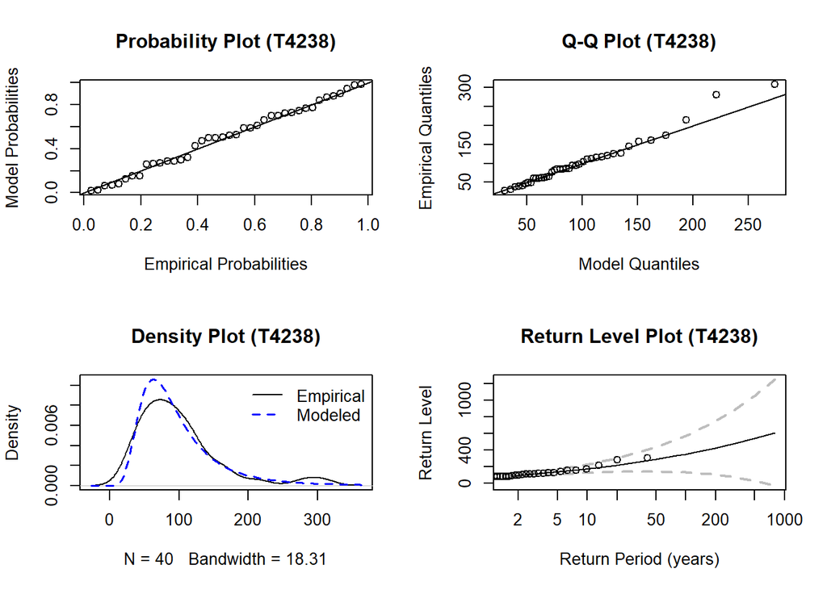

```r
# 95% confidence intervals for GEV parameters (normal approximation)
norm_cint_ts4 <- ci(GEV_ts4, alpha = 0.05, type = "parameter")
norm_cint_ts4
```

```
## fevd(x = maxima_ts4$max_rainfall, type = "GEV")
##
## [1] "Normal Approx."
##
##          95% lower CI   Estimate 95% upper CI
## location  57.57280963 70.3399071   83.1070045
## scale     25.22535971 35.5339501   45.8425406
## shape     -0.06820845  0.2204672    0.5091428
```

```r
# Return levels with 95% confidence intervals
ret_lev_ts4 <- return.level(GEV_ts4, return.period = c(100, 200, 500, 1000),
                            do.ci = TRUE)
ret_lev_ts4
```

```
## fevd(x = maxima_ts4$max_rainfall, type = "GEV")
##
## [1] "Normal Approx."
##
##                        95% lower CI Estimate 95% upper CI
## 100-year return level     132.32158 353.5428     574.7641
## 200-year return level     103.16402 427.2018     751.2396
## 500-year return level      29.66357 543.3814    1057.0993
## 1000-year return level    -60.90538 648.1791    1357.2637
```

As we can see, the confidence intervals for the shape parameter of the models fitted to stations T4219, T4220 and T4238 include zero, which suggests to investigate on the possibility of modelling those time series using a Gumbel distribution, where the shape parameter is exactly equal to zero.

```r
gum1<-fevd(maxima_ts1$max_rainfall, type="Gumbel")
gum1
```

```
##
## fevd(x = maxima_ts1$max_rainfall, type = "Gumbel")
##
## [1] "Estimation Method used: MLE"
##
##
##  Negative Log-Likelihood Value:  211.0888
##
##
##  Estimated parameters:
## location    scale
## 74.34376 39.71040
##
##  Standard Error Estimates:
## location    scale
## 6.604244 5.068923
##
##  Estimated parameter covariance matrix.
##          location    scale
## location 43.61604 10.36188
## scale    10.36188 25.69398
##
##  AIC = 426.1775
##
##  BIC = 429.5553
```

```r
#Return levels with 95% confidence intervals
ret.lev2<-return.level(gum1, return.period=c
                       (100,200,500,1000),do.ci=TRUE)
```

The AIC and BIC are both preferable with the Gumbel than with the GEV

```
##    Model      AIC      BIC
## 1    GEV 427.8980 432.9646
## 2 Gumbel 426.1775 429.5553
```

and we can also appreciate the reduction of the length of confidence intervals, both on parameters and on return levels.

```r
ret.lev2 # Gumbel CI
```

```
## fevd(x = maxima_ts1$max_rainfall, type = "Gumbel")
##
## [1] "Normal Approx."
##
##                        95% lower CI Estimate 95% upper CI
## 100-year return level      205.8077 257.0175     308.2273
## 200-year return level      226.7002 284.6426     342.5849
## 500-year return level      254.2081 321.0886     387.9691
## 1000-year return level     274.9686 348.6336     422.2987
```

```r
ret_lev_ts1 # GEV CI
```

```
## fevd(x = maxima_ts1$max_rainfall, type = "GEV")
##
## [1] "Normal Approx."
##
##                        95% lower CI Estimate 95% upper CI
## 100-year return level     135.56890 286.3705     437.1721
## 200-year return level     117.16729 326.1355     535.1037
## 500-year return level      76.41477 382.1279     687.8411
## 1000-year return level     31.77539 427.2807     822.7860
```

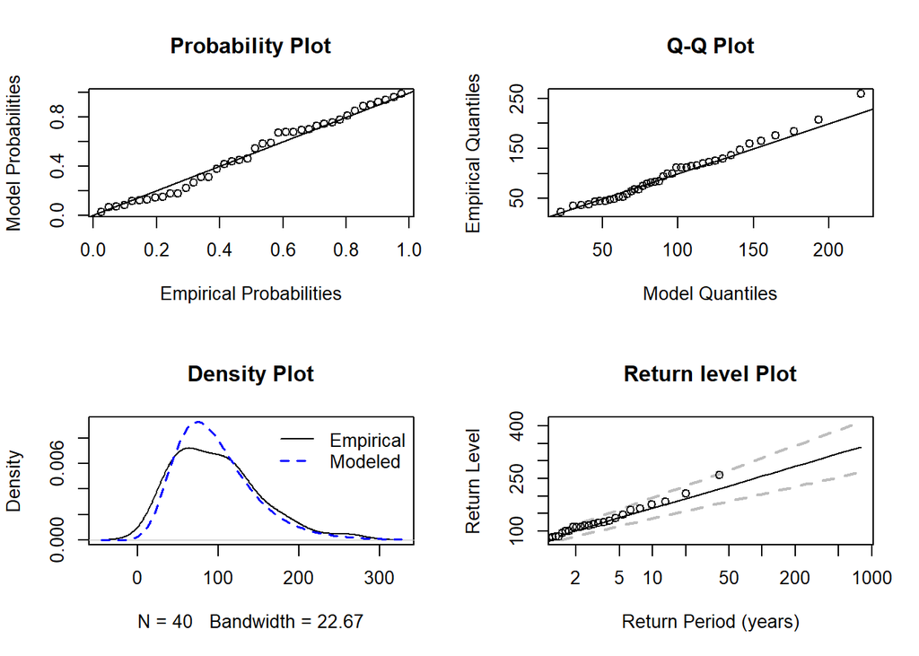

In order to decide whether the GEV distribution fits better than the Gumbel we run a likelihood ratio test. From the p-value, we cannot reject the null hypothesis that the Gumbel is enough, hence for station T4219 the Gumbel distribution is better than GEV.

```
##
##  Likelihood-ratio Test
##
## data:  maxima_ts1$max_rainfallmaxima_ts1$max_rainfall
## Likelihood-ratio = 0.27956, chi-square critical value = 3.8415, alpha =
## 0.0500, Degrees of Freedom = 1.0000, p-value = 0.597
## alternative hypothesis: greater
```

```
##    Model      AIC      BIC
## 1    GEV 404.3132 409.3798
## 2 Gumbel 402.3465 405.7242
```

```
##
##  Likelihood-ratio Test
##
## data:  maxima_ts2$max_rainfallmaxima_ts2$max_rainfall
## Likelihood-ratio = 0.033304, chi-square critical value = 3.8415, alpha
## = 0.0500, Degrees of Freedom = 1.0000, p-value = 0.8552
## alternative hypothesis: greater
```

```r
# Print the table
print(model_comparison3)
```

```
##    Model      AIC      BIC
## 1    GEV 372.8995 377.9661
## 2 Gumbel 386.0463 389.4240
```

```r
lr.test(gum3, GEV_ts3, alpha = 0.05)
```

```
##
##  Likelihood-ratio Test
##
## data:  maxima_ts3$max_rainfallmaxima_ts3$max_rainfall
## Likelihood-ratio = 15.147, chi-square critical value = 3.8415, alpha =
## 0.0500, Degrees of Freedom = 1.0000, p-value = 9.947e-05
## alternative hypothesis: greater
```

For station T4237, the initial GEV fitting revealed that the 95% confidence interval (using the normal approximation) for the shape parameter included only positive values. However, the confidence intervals for the return levels were significantly wider compared to those of the other rainfall stations, therefore caution is needed in interpreting the estimates and drawing inferences.

## Generalized Pareto Distribution: peak over threshold approach.

To fit a Generalized Pareto Distribution (GPD), we employ the Peak Over Threshold (POT) method, which focuses on modeling the tail behavior of a distribution by using data points that exceed a chosen threshold. The goal is to select a threshold high enough to ensure that the excesses (values above the threshold) follow the GPD, as guaranteed by the Pickands-Balkema-de Haan Theorem. A critical aspect of this approach is the choice of the threshold: it must be sufficiently high to justify the GPD approximation while retaining enough data points to enable reliable parameter estimation. This balance is essential, as overly high thresholds reduce the sample size and increase estimation uncertainty, whereas low thresholds may violate the assumptions of the theorem. If the assumptions are satisfied — that is, the exceedances are independent and identically distributed and originate from the same population — then the excesses above the threshold can be modeled using the GPD.

Now, we are going to choose an appropriate threshold making use of mean excess plots (the sample mean of excesses when the value of the threshold u changes) and the “gpd.fitrange” function which fits the GPD model for different values of the threshold u. Then we are going to fit the final model, plot the diagnostics and compare it with the same model that includes a trend in the time component. The same steps are repated for all four rain stations.

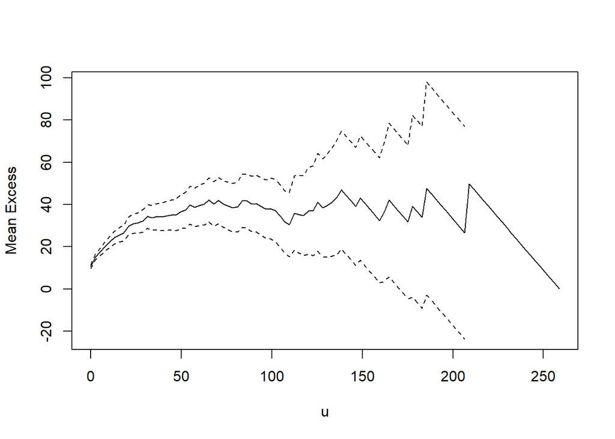

```r
# TS1
mrl.plot(ts1$r_amount)
```

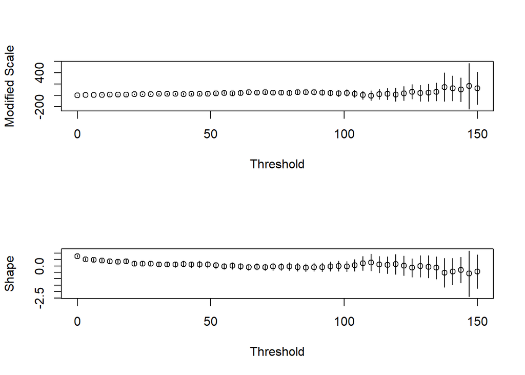

```r
gpd.fitrange(ts1$r_amount, 0, 150, 50)
```

By looking at the second plot, it seems that after u = 100 the estimates of the shape and modified scale parameters become more unstable, therefore a value between 50 and 100 must be picked. In order to balance the trade-off between bias and variance, a threshold u = 50 has been chosen.

```r
gpd1 <- gpd.fit(ts1$r_amount, 50)
```

```
## $threshold
## [1] 50
##
## $nexc
## [1] 90
##
## $conv
## [1] 0
##
## $nllh
## [1] 413.8641
##
## $mle
## [1] 33.91075610  0.07468908
##
## $rate
## [1] 0.01232202
##
## $se
## [1] 5.7842626 0.1342977
```

```r
#Number of excesses
gpd1$nexc
```

```
## [1] 90
```

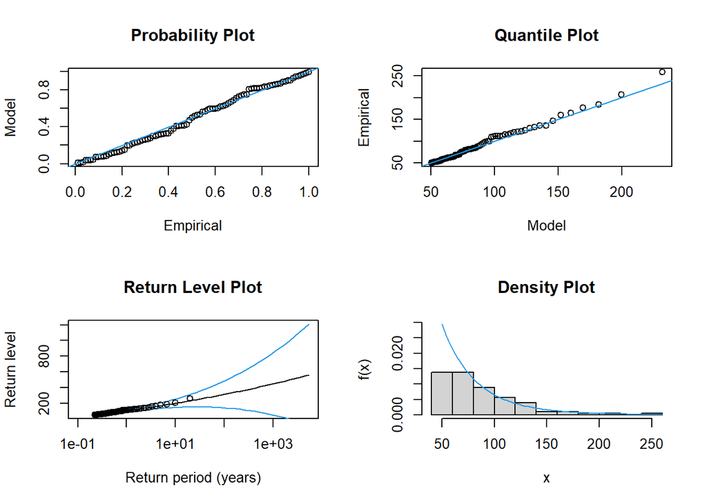

```r
# Plot diagnostics
gpd.diag(gpd1)
```

We can also include a time trend and check whether this model better explains the evolution in time of the event under study.

After comparing the two models through a likelihood ratio test, there is no evidence to reject the null hypothesis, therefore the simpler model (without trend) is enough.

```r
# Compare the two models with likelihood ratio test
lrt1 <- 2 * (gpd1$nllh - gpd.t1$nllh)
print(1 - pchisq(lrt1, 1))
```

```
## [1] 0.9103683
```

The following code develops the same arguments for the other three rain stations:

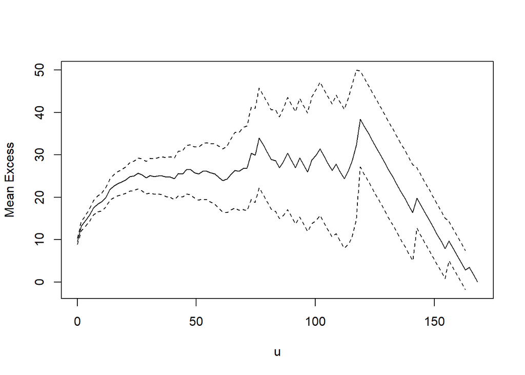

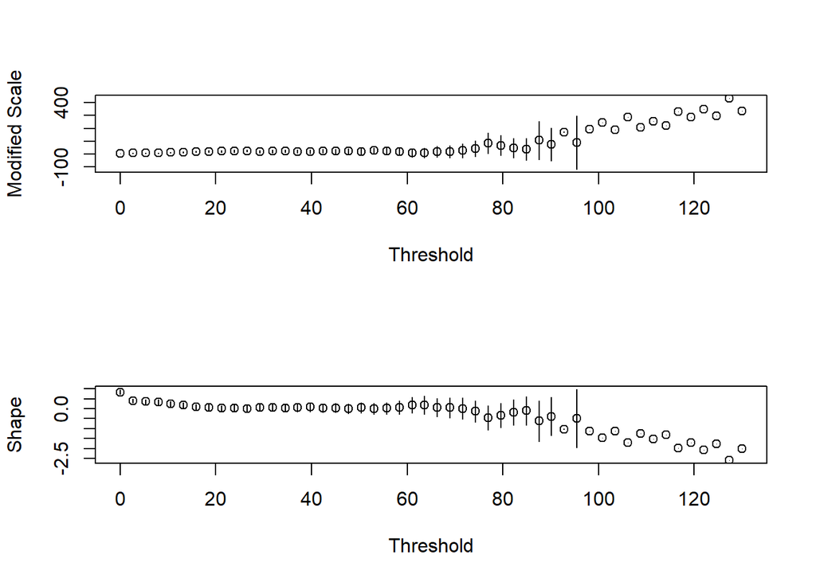

```r
gpd2 <- gpd.fit(ts2$r_amount, 45)
```

```
## $threshold
## [1] 45
##
## $nexc
## [1] 88
##
## $conv
## [1] 0
##
## $nllh
## [1] 373.0746
##
## $mle
## [1] 24.62351121  0.03577414
##
## $rate
## [1] 0.01204819
##
## $se
## [1] 3.9463549 0.1197856
```

```r
gpd2$nexc
```

```
## [1] 88
```

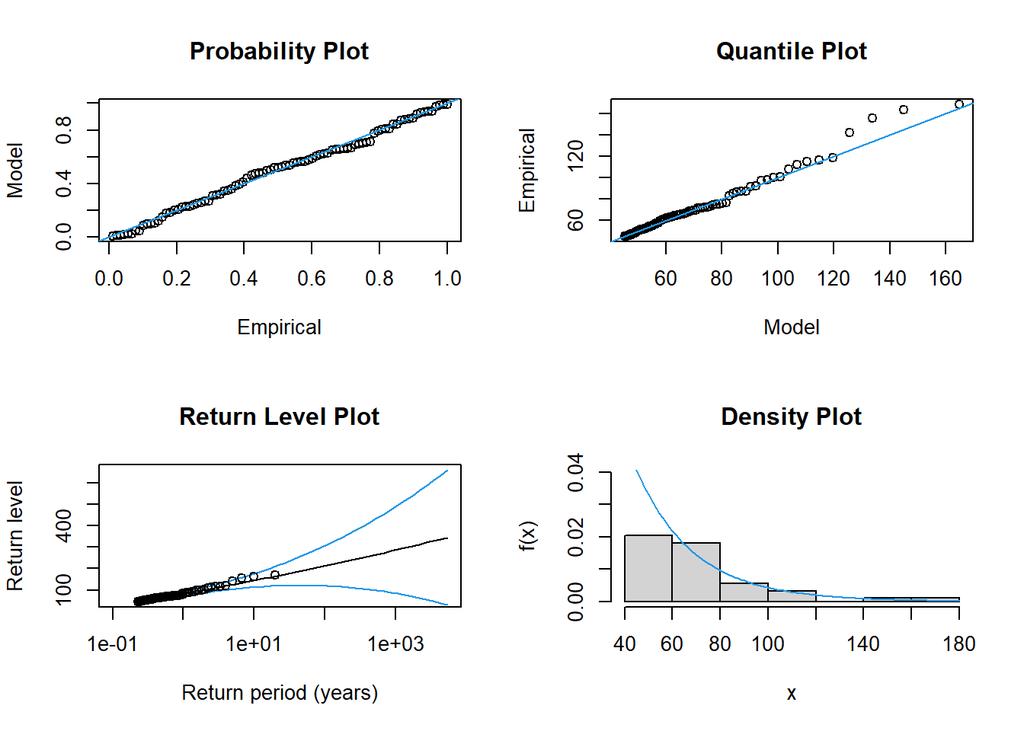

```r
# Plot diagnostics
gpd.diag(gpd2)
```

```r
# Compare the two models with likelihood ratio test
lrt2 <- 2 * (gpd2$nllh - gpd.t2$nllh)
print(1 - pchisq(lrt2, 1))
```

```
## [1] 0.1669813
```

Again, no evidence to reject the null hypothesis. The simpler model is again better.

For the station T4237 it seems that a reasonable threshold should be between 40 and 50 Let’s pick u = 40

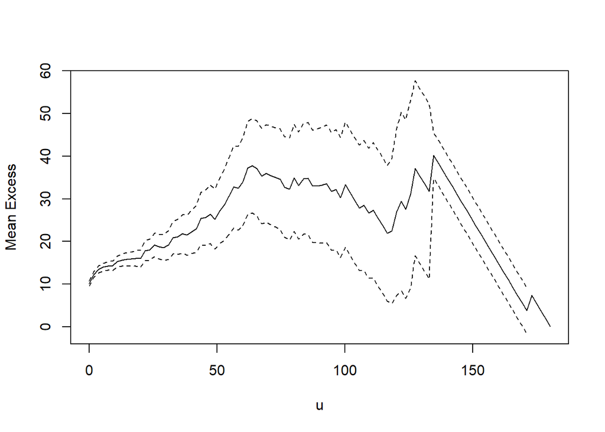

```r
mrl.plot(ts3$r_amount)
```

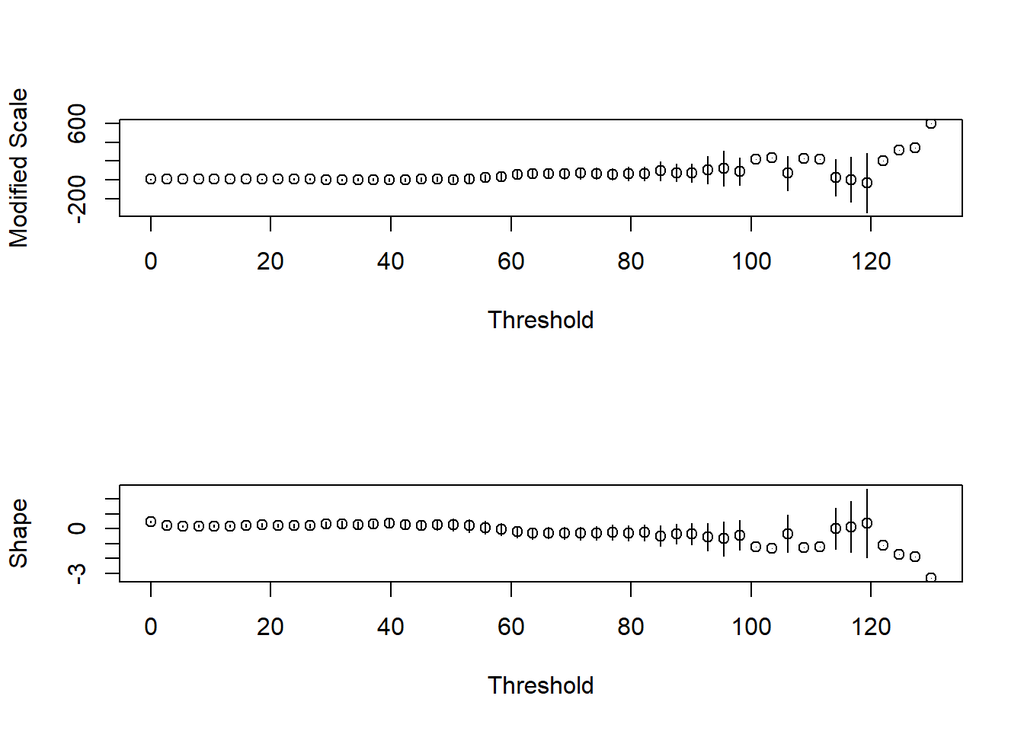

```r
gpd.fitrange(ts3$r_amount, 0, 130, 50)
```

```r
gpd3 <- gpd.fit(ts3$r_amount, 40)
```

```
## $threshold
## [1] 40
##
## $nexc
## [1] 121
##
## $conv
## [1] 0
##
## $nllh
## [1] 491.4586
##
## $mle
## [1] 14.9856177  0.3544132
##
## $rate
## [1] 0.01656627
##
## $se
## [1] 2.4273461 0.1378968
```

```r
gpd3$nexc
```

```
## [1] 121
```

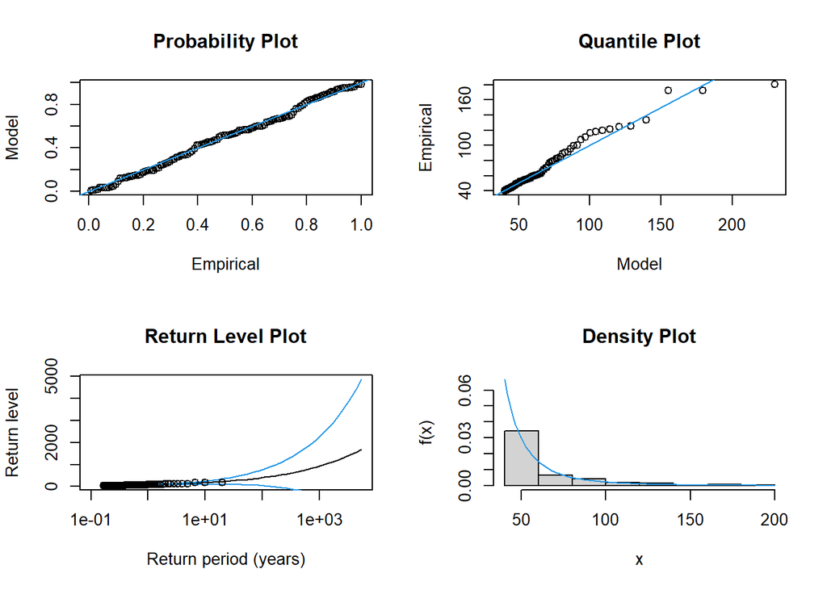

```r
# Plot diagnostics
gpd.diag(gpd3)
```

Once again the simpler model is preferred.

```r
# Compare the two models with likelihood ratio test
lrt3 <- 2 * (gpd3$nllh - gpd.t3$nllh)
print(1 - pchisq(lrt3, 1))
```

```
## [1] 0.2057382
```

Here’s the model for station T4238, where a good value of u lies between 50 and 70.

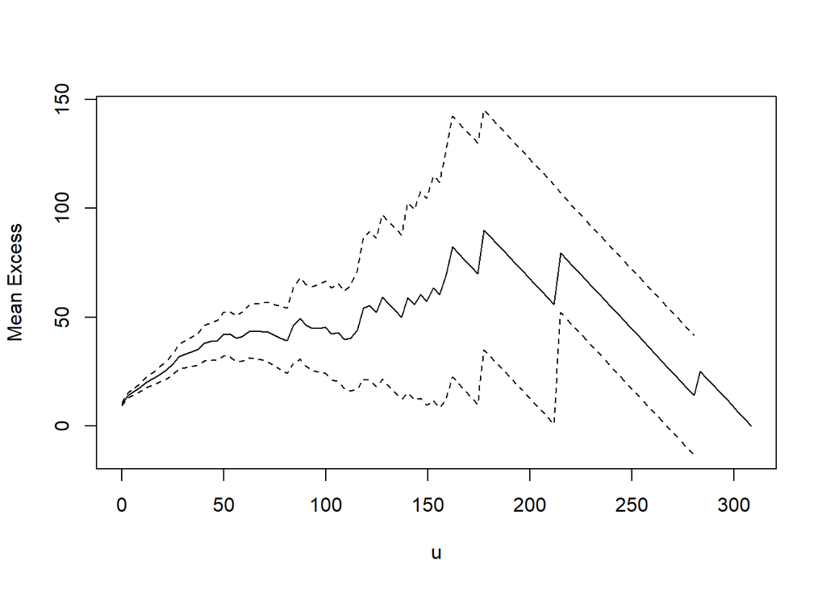

```r
mrl.plot(ts4$r_amount)
```

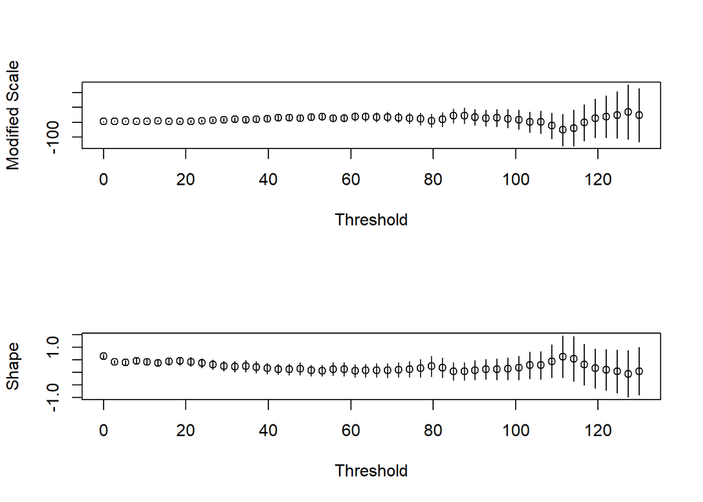

```r
gpd.fitrange(ts4$r_amount, 0, 130,50)
```

```r
gpd4 <- gpd.fit(ts4$r_amount, 50)
```

```
## $threshold
## [1] 50
##
## $nexc
## [1] 82
##
## $conv
## [1] 0
##
## $nllh
## [1] 388.0403
##
## $mle
## [1] 38.73401756  0.07516631
##
## $rate
## [1] 0.01122673
##
## $se
## [1] 6.1261058 0.1135306
```

```r
gpd4$nexc
```

```
## [1] 82
```

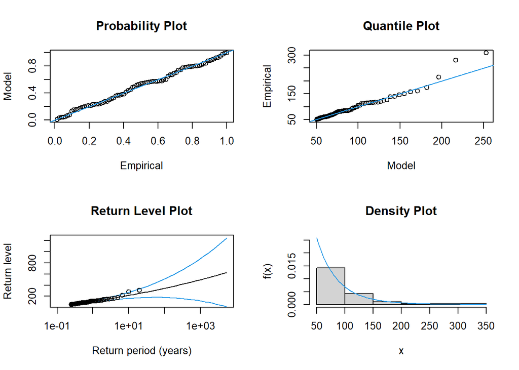

```r
# Plot diagnostics
gpd.diag(gpd4)
```

Given the high p-value, once again the simpler model is preferred.

```r
# Compare the two models with likelihood ratio test
lrt4 <- 2 * (gpd4$nllh - gpd.t4$nllh)
print(1 - pchisq(lrt4, 1))
```

```
## [1] 0.9695055
```

```
##   Return_Period  Lower_CI Estimate Upper_CI
## 1           100 140.79743 312.6856 484.5738
## 2           200 123.77652 350.8105 577.8445
## 3           500  88.36747 404.3456 720.3238
## 4          1000  50.76056 447.3568 843.9530
```

```
##   Return_Period  Lower_CI Estimate Upper_CI
## 1           100 119.25720 212.3463 305.4355
## 2           200 113.42401 233.7965 354.1690
## 3           500  99.87970 262.9736 426.0674
## 4          1000  85.00564 285.6838 486.3619
```

```
##   Return_Period   Lower_CI Estimate  Upper_CI
## 1           100   46.46933 406.8781  767.2869
## 2           200  -24.88880 520.7524 1066.3936
## 3           500 -194.64043 721.3094 1637.2593
## 4          1000 -408.18210 922.6846 2253.5512
```

```
##   Return_Period Lower_CI Estimate Upper_CI
## 1           100 178.5385 344.5261 510.5138
## 2           200 169.6394 387.7388 605.8381
## 3           500 146.1060 448.3983 750.6906
## 4          1000 118.4257 497.1174 875.8091
```

For station T4237, as we can see from the confidence intervals of return level estimates, the uncertainty is so high that the lower bounds of the intervals become negative. Therefore we cannot say anything about the interpretation of these estimates. We previously got the same result from GEV estimation.

As one would expect by modelling beyond the observed data range, for all stations the return levels increase as the return period increases and the confidence intervals become wider with increasing return periods, reflecting more uncertainty in the estimates of more extreme events. Focusing only on stations T4219, T4220 and T4238, we can see that station T4238 seems to have the highest return levels, indicating it is the most prone to extreme rainfall events. Regarding uncertainty, station T4220 has the narrowest confidence intervals, suggesting a more reliable model fit.